Pular para o conteúdo principal

# Tutorial: do dado bruto à regressão

Como reproduzir em R a análise “Juros e bolsa: como os setores da B3 reagem à Selic”

Autores

Integrante 1

Integrante 2

Integrante 3

Integrante 4

Integrante 5

Data de Publicação

18 de novembro de 2026

Disciplina

REC3302 — Introdução ao R Aplicado à Economia e Finanças (FEA-RP/USP)

# O que você vai aprender

Este tutorial reconstrói, passo a passo, a análise do relatório de mercado: baixar dados do Banco Central e do Yahoo Finance, transformar cotações diárias em retornos mensais, montar a base, validá-la e estimar regressões com erros-padrão robustos. Cada bloco de código pode ser copiado e rodado no seu computador.

Os passos de **coleta** (1 e 2) dependem de internet e aparecem só como código. A partir do passo 3, todo o código **é executado de verdade** na geração deste documento, usando os dados brutos salvos em `dados/brutos/`, e os resultados são conferidos com a base oficial do projeto.

## Antes de começar

- **R 4.6** e uma IDE (Positron ou RStudio). Abra a **pasta do projeto** como diretório de trabalho (no Positron: *File > Open Folder*). Todos os caminhos são relativos a ela.
- **Pacotes:** rode uma vez `source("scripts/00_setup.R")`, que instala tidyverse, tidyquant, rbcb, jsonlite, httr2, zoo, broom, lmtest e sandwich.
- **Atalho:** `source("rodar_tudo.R")` monta a base, valida e roda a análise a partir dos dados salvos, reproduzindo os resultados do relatório. Para baixar dados novos, mude `BAIXAR_DADOS <- TRUE` no início do arquivo (isso substitui os dados salvos e pode mudar os números). Este tutorial explica o que acontece dentro de cada script.

```
projeto_juros_bolsa/
├── rodar_tudo.R            # roda os scripts em ordem (coleta só se BAIXAR_DADOS = TRUE)
├── montar_entregaveis.R    # empacota os entregáveis em .zip
├── _quarto.yml             # configuração do Quarto
├── scripts/
│   ├── parametros.R        # período, pastas e composição das cestas
│   ├── 00_setup.R          # instala pacotes
│   ├── 01_coleta_bcb.R     # Selic e IPCA (Banco Central)
│   ├── 02_coleta_mercado.R # preços das ações (Yahoo Finance)
│   ├── 03_base_mensal.R    # monta a base mensal
│   ├── 04_validacao.R      # checagens da base
│   └── 05_analise.R        # gráficos, tabelas e regressões
├── dados/brutos/           # dados como vieram das fontes (+ data_coleta.txt)
├── dados/tratados/         # base mensal pronta
├── dados/dicionario_dados.md  # descrição de cada variável
├── resultados/             # figuras (PNG) e tabelas (CSV)
├── relatorio/              # relatório e este tutorial (Quarto)
└── entregaveis/            # pacotes .zip gerados por montar_entregaveis.R
```

```r
library(tidyverse)   # manipulação de dados e gráficos
library(lmtest)      # coeftest(): testes dos coeficientes
library(sandwich)    # NeweyWest(): erros-padrão robustos
```

# Passo 1 — Coletar a Selic e o IPCA no Banco Central

O Banco Central publica suas séries no **SGS** (Sistema Gerenciador de Séries Temporais), com uma API gratuita. Usamos a **série 432** (meta Selic, % ao ano, um valor por dia) e a **série 433** (IPCA, variação % no mês). Uma consulta é só uma URL:

```r
library(httr2)

url <- paste0("https://api.bcb.gov.br/dados/serie/bcdata.sgs.432/dados?formato=json",
              "&dataInicial=01/12/2014&dataFinal=30/11/2017")

selic <- request(url) |>
  req_retry(max_tries = 6) |>        # tenta de novo se o servidor falhar (502, 503...)
  req_perform() |>
  resp_body_string() |>
  jsonlite::fromJSON()               # vira uma tabela com as colunas data e valor
```

**DicaDois cuidados com a API do BCB**

1. **Janela máxima de 10 anos por consulta.** O script `01_coleta_bcb.R` divide o período em blocos de 3 anos, baixa cada um e junta tudo com `bind_rows()`.
2. **Instabilidade.** A API às vezes devolve uma página de erro (XML ou HTML) no lugar do JSON. O script confere a resposta, tenta de novo com espera crescente e, se ainda falhar, usa o último arquivo salvo em `dados/brutos/`, com um aviso.

O IPCA é baixado desde **12 meses antes** do início da análise, para que o IPCA acumulado em 12 meses já exista no primeiro mês da base.

# Passo 2 — Coletar os preços das ações

O pacote **tidyquant** baixa cotações do Yahoo Finance com uma linha. As ações da B3 levam o sufixo `.SA`; o Ibovespa é `^BVSP`. A lista fica em `scripts/parametros.R`, na tabela `CESTAS`:

```r
library(tidyquant)
source("scripts/parametros.R")   # define CESTAS, DATA_INICIO e DATA_FIM

precos <- tq_get(CESTAS$ticker, get = "stock.prices",
                 from = DATA_INICIO, to = DATA_FIM)
write_csv(precos, "dados/brutos/yahoo_precos_diarios.csv")
```

A coluna que importa é `adjusted`: o preço **ajustado** por dividendos e desdobramentos. Sem esse ajuste, um desdobramento de 1 para 2 apareceria como uma queda de 50% no preço.

**Nota**

O Yahoo revisa os preços ajustados com o tempo. Por isso os dados brutos ficam salvos: eles registram exatamente a versão usada na análise.

# Passo 3 — Da cotação diária ao retorno mensal

A partir daqui, tudo roda sobre os arquivos salvos. O **preço do mês** é o preço ajustado do **último pregão** do mês, e o **retorno mensal** é a variação percentual simples:

$$r_t = \left(\frac{P_t}{P_{t-1}} - 1\right) \times 100$$

```r
precos <- read_csv("dados/brutos/yahoo_precos_diarios.csv", show_col_types = FALSE)

ret_ativos <- precos |>
  filter(!is.na(adjusted)) |>
  arrange(symbol, date) |>
  mutate(mes = floor_date(date, "month")) |>        # 2015-01-23 vira 2015-01-01
  group_by(symbol, mes) |>
  summarise(preco = last(adjusted), .groups = "drop_last") |>   # último pregão do mês
  mutate(ret = (preco / lag(preco) - 1) * 100) |>   # lag() = valor do mês anterior
  ungroup()

ret_ativos |> filter(symbol == "ITUB4.SA") |> head(4)
```

| symbol | mes | preco | ret |
| --- | --- | --- | --- |
| ITUB4.SA | 2014-12-01 | 8.609198 | NA |
| ITUB4.SA | 2015-01-01 | 8.189746 | -4.872135 |
| ITUB4.SA | 2015-02-01 | 9.315389 | 13.744539 |
| ITUB4.SA | 2015-03-01 | 9.015387 | -3.220490 |

O primeiro mês (dez/2014) fica sem retorno, porque não há mês anterior. É por isso que a coleta começa em dezembro: para ter o retorno de janeiro de 2015.

**Conferência:** os retornos calculados aqui devem ser iguais aos da base oficial do projeto.

```r
oficial <- read_csv("dados/tratados/retornos_ativos_mensal.csv", show_col_types = FALSE)

inner_join(ret_ativos, oficial, by = c("symbol", "mes"), suffix = c("", "_oficial")) |>
  summarise(meses_comparados = n(),
            maior_diferenca  = max(abs(ret - ret_oficial)))
```

| meses_comparados | maior_diferenca |
| --- | --- |
| 1410 | 0 |

# Passo 4 — Selic mensal, variação e ciclo

A meta Selic é diária. Para cada mês, pegamos o valor vigente no **último dia**, calculamos a **variação no mês** (em pontos percentuais) e classificamos o **ciclo**:

```r
selic_d <- read_csv("dados/brutos/bcb_selic_meta.csv", show_col_types = FALSE)

selic_m <- selic_d |>
  mutate(mes = floor_date(date, "month")) |>
  group_by(mes) |>
  summarise(selic = last(selic_meta)) |>
  mutate(delta_selic = selic - lag(selic),
         ciclo = case_when(delta_selic > 0 ~ "alta",
                           delta_selic < 0 ~ "queda")) |>   # meses sem mudança ficam NA...
  fill(ciclo, .direction = "downup") |>                     # ...e herdam o ciclo vigente
  mutate(ciclo_alta = as.integer(ciclo == "alta"))

selic_m |> filter(mes >= "2021-01-01", mes <= "2021-06-01")
```

| mes | selic | delta_selic | ciclo | ciclo_alta |
| --- | --- | --- | --- | --- |
| 2021-01-01 | 2.00 | 0.00 | queda | 0 |
| 2021-02-01 | 2.00 | 0.00 | queda | 0 |
| 2021-03-01 | 2.75 | 0.75 | alta | 1 |
| 2021-04-01 | 2.75 | 0.00 | alta | 1 |
| 2021-05-01 | 3.50 | 0.75 | alta | 1 |
| 2021-06-01 | 4.25 | 0.75 | alta | 1 |

O truque está em `fill()`: em fev/2021 a Selic não mudou, então o mês herda o ciclo de queda que vinha de antes; em mar/2021 o Copom subiu os juros e começou um ciclo de alta, que segue nos meses seguintes até o próximo corte.

# Passo 5 — IPCA em 12 meses e juro real

O IPCA acumulado em 12 meses multiplica os 12 fatores mensais. A função `rollapplyr()`, do pacote zoo, aplica esse produto numa janela móvel:

```r
ipca_m <- read_csv("dados/brutos/bcb_ipca.csv", show_col_types = FALSE) |>
  transmute(mes = floor_date(date, "month"), ipca) |>
  mutate(ipca_12m = (zoo::rollapplyr(1 + ipca / 100, 12, prod, fill = NA) - 1) * 100)

juro <- inner_join(selic_m, ipca_m, by = "mes") |>
  mutate(juro_real = ((1 + selic / 100) / (1 + ipca_12m / 100) - 1) * 100)

juro |> select(mes, selic, ipca_12m, juro_real) |> tail(3)
```

| mes | selic | ipca_12m | juro_real |
| --- | --- | --- | --- |
| 2026-07-01 | 14.25 | 4.443025 | 9.389785 |
| 2026-08-01 | 14.00 | 4.223453 | 9.380372 |
| 2026-09-01 | 13.75 | 4.576120 | 8.772443 |

O **juro real ex-post** desconta a inflação dos últimos 12 meses da Selic. Note que é uma divisão, e não uma subtração: $(1 + i)/(1 + \pi) - 1$.

# Passo 6 — Montar as cestas e a base mensal

Cada cesta é a **média simples** dos retornos das três ações do setor. Juntamos tudo numa tabela com **uma linha por mês**:

```r
source("scripts/parametros.R")   # traz a tabela CESTAS (ticker -> setor)

setores <- ret_ativos |>
  left_join(CESTAS, by = c("symbol" = "ticker")) |>
  filter(!is.na(ret)) |>
  group_by(setor, mes) |>
  summarise(ret = mean(ret), .groups = "drop") |>
  mutate(setor = if_else(setor == "mercado", "ibov", setor)) |>
  pivot_wider(names_from = setor, values_from = ret, names_prefix = "ret_")

# Mesmo período da base oficial (o 03 usa jan/2015 até o último mês completo com IPCA divulgado)
base_oficial <- read_csv("dados/tratados/base_mensal.csv", show_col_types = FALSE)

base <- setores |>
  inner_join(juro, by = "mes") |>
  filter(mes >= min(base_oficial$mes), mes <= max(base_oficial$mes))

dim(base)
```

```
[1] 141  12
```

**Conferência** com a base oficial (`dados/tratados/base_mensal.csv`):

```r
all.equal(base |> select(mes, ret_bancos, ret_varejo, ret_utilities, ret_ibov,
                         selic, delta_selic, ciclo),
          base_oficial |> select(mes, ret_bancos, ret_varejo, ret_utilities, ret_ibov,
                                 selic, delta_selic, ciclo),
          check.attributes = FALSE)
```

```
[1] TRUE
```

`TRUE` significa que reconstruímos a base exatamente. Daqui em diante usamos a base oficial.

```r
base <- base_oficial
```

# Passo 7 — Validar antes de analisar

Uma base com buracos ou valores absurdos produz conclusões erradas sem nenhuma mensagem de erro. O script `04_validacao.R` faz 7 checagens; três delas:

```r
meses_esperados <- seq(min(base$mes), max(base$mes), by = "month")

c(meses_consecutivos = identical(base$mes, meses_esperados),
  sem_valor_ausente  = !anyNA(base),
  selic_plausivel    = all(between(base$selic, 1, 20)))
```

```
meses_consecutivos  sem_valor_ausente    selic_plausivel
              TRUE               TRUE               TRUE
```

O script também lista os retornos individuais acima de 30% em módulo. Eles não são erro, mas merecem atenção: a MGLU3 aparece muitas vezes nessa lista, e isso motivou o teste de robustez do passo 12.

# Passo 8 — Estatística descritiva

O **retorno acumulado** compõe os retornos mensais: $\prod (1 + r_t) - 1$. Somar os retornos daria um resultado errado.

```r
ret_long <- base |>
  select(mes, starts_with("ret_")) |>
  pivot_longer(-mes, names_to = "serie", names_prefix = "ret_", values_to = "ret")

ret_long |>
  group_by(serie) |>
  summarise(media_mensal = mean(ret),
            acumulado    = (prod(1 + ret / 100) - 1) * 100,
            vol_anual    = sd(ret) * sqrt(12))   # volatilidade mensal x raiz de 12
```

| serie | media_mensal | acumulado | vol_anual |
| --- | --- | --- | --- |
| bancos | 1.418346 | 319.0880 | 31.05809 |
| ibov | 1.132502 | 272.6278 | 21.41045 |
| utilities | 1.925336 | 862.5287 | 27.08591 |
| varejo | 1.831071 | 502.2020 | 36.75768 |

E o retorno médio em cada ciclo, com um **teste t** para saber se a diferença é real:

```r
base |> group_by(ciclo) |> summarise(varejo = mean(ret_varejo), meses = n())
```

| ciclo | varejo | meses |
| --- | --- | --- |
| alta | 0.9331767 | 68 |
| queda | 2.6674661 | 73 |

```r
t.test(ret_varejo ~ ciclo, data = base)$p.value
```

```
[1] 0.3369997
```

A diferença parece grande (quase o triplo na queda), mas o p-valor mostra que ela **não é estatisticamente significativa**: o varejo oscila tanto que médias de cerca de 70 meses ainda têm muita incerteza. Esta é uma lição importante: um gráfico de médias pode enganar.

# Passo 9 — Correlações defasadas

A bolsa pode demorar a reagir. Comparamos o retorno do mês $t$ com a variação da Selic em $t$, $t-1$, $t-2$ e $t-3$. A função `lag(x, k)` desloca a série $k$ meses:

```r
expand_grid(setor = c("bancos", "varejo", "utilities"), defasagem = 0:3) |>
  mutate(teste = map2(setor, defasagem, \(s, k)
           cor.test(base[[paste0("ret_", s)]], lag(base$delta_selic, k))),
         correlacao = map_dbl(teste, \(t) t$estimate),
         p_valor    = map_dbl(teste, \(t) t$p.value)) |>
  select(-teste) |>
  filter(setor == "varejo")
```

| setor | defasagem | correlacao | p_valor |
| --- | --- | --- | --- |
| varejo | 0 | -0.1880349 | 0.0255574 |
| varejo | 1 | -0.1901348 | 0.0244424 |
| varejo | 2 | -0.1950489 | 0.0213932 |
| varejo | 3 | -0.1309643 | 0.1257470 |

`expand_grid()` cria todas as combinações de setor e defasagem, e `map2()` roda um teste para cada uma. Assim, um único bloco de código faz os 12 testes.

# Passo 10 — Regressão com erros-padrão de Newey-West

O modelo central compara o retorno do setor com a variação da Selic, **controlando pelo Ibovespa**:

$$r_{varejo,t} = \alpha + \beta_1\,\Delta Selic_t + \beta_2\, r_{Ibov,t} + \varepsilon_t$$

```r
m1 <- lm(ret_varejo ~ delta_selic + ret_ibov, data = base)

# Erros-padrão comuns (supõem variância constante e meses independentes)
coeftest(m1)
```

```
t test of coefficients:

            Estimate Std. Error t value Pr(>|t|)
(Intercept)  0.60380    0.67109  0.8997  0.36983
delta_selic -3.36180    1.47417 -2.2805  0.02411 *
ret_ibov     1.12579    0.10732 10.4895  < 2e-16 ***
---
Signif. codes:  0 '***' 0.001 '**' 0.01 '*' 0.05 '.' 0.1 ' ' 1
```

```r
# Erros-padrão de Newey-West: robustos a variância variável e a autocorrelação
coeftest(m1, vcov. = NeweyWest(m1, lag = 3, prewhite = FALSE))
```

```
t test of coefficients:

            Estimate Std. Error t value  Pr(>|t|)
(Intercept)  0.60380    0.73305  0.8237  0.411541
delta_selic -3.36180    1.18133 -2.8458  0.005106 **
ret_ibov     1.12579    0.12305  9.1488 6.783e-16 ***
---
Signif. codes:  0 '***' 0.001 '**' 0.01 '*' 0.05 '.' 0.1 ' ' 1
```

Os **coeficientes são os mesmos** nas duas tabelas; o que muda é o **erro-padrão** e, com ele, o p-valor. Os erros-padrão comuns supõem que a volatilidade é constante e que os meses são independentes, duas hipóteses pouco realistas em finanças: a volatilidade muda com o tempo (veja março de 2020) e meses próximos podem estar correlacionados. O Newey-West continua válido nessas situações, em amostras grandes; `lag = 3` considera a correlação de até 3 meses.

A correção **não aumenta sempre** o erro-padrão. Aqui, o erro-padrão da Selic caiu de 1,47 para 1,18. O motivo para usar Newey-West não é obter um p-valor menor ou maior, e sim ter um erro-padrão **válido** para este tipo de dado.

**Como ler:** $\beta_1 \approx$ -3,36 significa que, num mês em que a Selic sobe 1 p.p., o varejo rende cerca de 3,4 p.p. a menos do que o esperado pelo movimento do Ibovespa.

# Passo 11 — Interação: o efeito muda com o ciclo?

Para testar a H4, multiplicamos a variação da Selic pela dummy de ciclo de alta. Na fórmula do R, `a * b` inclui `a`, `b` e a interação `a:b`:

```r
m2 <- lm(ret_varejo ~ delta_selic * ciclo_alta + ret_ibov, data = base)
V  <- NeweyWest(m2, lag = 3, prewhite = FALSE)
b  <- coef(m2)

# Efeito na queda: beta1.  Efeito na alta: beta1 + beta3.
efeito_alta <- b[["delta_selic"]] + b[["delta_selic:ciclo_alta"]]
ep_alta <- sqrt(V["delta_selic", "delta_selic"] +
                V["delta_selic:ciclo_alta", "delta_selic:ciclo_alta"] +
                2 * V["delta_selic", "delta_selic:ciclo_alta"])

c(efeito_queda = b[["delta_selic"]], efeito_alta = efeito_alta, erro_padrao_alta = ep_alta)
```

```
    efeito_queda      efeito_alta erro_padrao_alta
       -5.143601        -2.684597         1.838780
```

O erro-padrão de uma soma de coeficientes precisa da **covariância** entre eles: $Var(\beta_1 + \beta_3) = Var(\beta_1) + Var(\beta_3) + 2\,Cov(\beta_1, \beta_3)$. Somar os erros-padrão individuais estaria errado. Para saber se a diferença entre os ciclos é real, basta olhar o p-valor de $\beta_3$ em `coeftest(m2, vcov. = V)`.

# Passo 12 — Robustez: o resultado depende de uma ação?

Refazemos a cesta de varejo sem a MGLU3:

```r
ativos <- read_csv("dados/tratados/retornos_ativos_mensal.csv", show_col_types = FALSE)

varejo_sem_mglu <- ativos |>
  filter(setor == "varejo", symbol != "MGLU3.SA") |>
  group_by(mes) |>
  summarise(ret_varejo_sem_mglu = mean(ret))

m_sem <- lm(ret_varejo_sem_mglu ~ delta_selic + ret_ibov,
            data = left_join(base, varejo_sem_mglu, by = "mes"))

coeftest(m_sem, vcov. = NeweyWest(m_sem, lag = 3, prewhite = FALSE))["delta_selic", ]
```

```
  Estimate Std. Error    t value   Pr(>|t|)
-0.2062053  0.9288809 -0.2219933  0.8246473
```

Sem a MGLU3, o coeficiente fica perto de zero e deixa de ser significativo. **Sempre teste se o resultado sobrevive à retirada de observações extremas**, principalmente com amostras pequenas.

# Passo 13 — Um gráfico no padrão do projeto

Todos os gráficos usam a mesma paleta por setor, título com a conclusão, subtítulo explicando a medida e a fonte no rodapé:

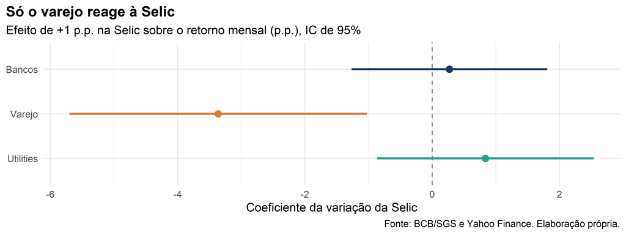

```r
cores <- c(Bancos = "#1F3864", Varejo = "#E07A2E", Utilities = "#2A9D8F")

coefs <- map(c(Bancos = "bancos", Varejo = "varejo", Utilities = "utilities"), \(s) {
  m <- lm(reformulate(c("delta_selic", "ret_ibov"), paste0("ret_", s)), data = base)
  ct <- coeftest(m, vcov. = NeweyWest(m, lag = 3, prewhite = FALSE))
  tibble(beta = ct["delta_selic", 1], ep = ct["delta_selic", 2],
         t_crit = qt(0.975, df = m$df.residual))   # valor crítico do IC de 95%
}) |>
  list_rbind(names_to = "setor") |>
  mutate(setor = factor(setor, levels = c("Utilities", "Varejo", "Bancos")))  # ordem no eixo

ggplot(coefs, aes(beta, setor, color = setor)) +
  geom_vline(xintercept = 0, linetype = "dashed", color = "grey50") +
  geom_pointrange(aes(xmin = beta - t_crit * ep, xmax = beta + t_crit * ep), linewidth = 0.9) +
  scale_color_manual(values = cores, guide = "none") +
  labs(title = "Só o varejo reage à Selic",
       subtitle = "Efeito de +1 p.p. na Selic sobre o retorno mensal (p.p.), IC de 95%",
       x = "Coeficiente da variação da Selic", y = NULL,
       caption = "Fonte: BCB/SGS e Yahoo Finance. Elaboração própria.") +
  theme_minimal(base_size = 11) +
  theme(plot.title = element_text(face = "bold"), plot.title.position = "plot")
```

Para salvar em alta resolução: `ggsave("figura.png", width = 8, height = 4, dpi = 300, bg = "white")`.

# Passo 14 — Gerar o relatório e os entregáveis

O relatório e este tutorial são documentos **Quarto** (`.qmd`), que misturam texto e código R. Os números do texto do relatório não são digitados: são lidos de `resultados/tabelas/` com código *inline*, por exemplo `` `r num(v$estimate)` ``. Os títulos dos gráficos também são calculados no `05_analise.R`. Para regenerar tudo:

```r
source("rodar_tudo.R")            # base, validação e análise (com os dados salvos)
source("montar_entregaveis.R")    # renderiza relatório e tutorial e gera os .zip
# ou, só o relatório, no terminal na pasta do projeto:  quarto render
```

Se os dados forem atualizados (`BAIXAR_DADOS <- TRUE`), os números mudam sozinhos, mas as frases interpretativas do relatório precisam ser relidas.

# Erros comuns

| Sintoma | Causa provável | Solução |
| --- | --- | --- |
| `Diretório de trabalho errado` | O R não está na pasta do projeto | Abrir a **pasta** no Positron (*File > Open Folder*) |
| Aviso `Falha ao baixar a série ... usando o arquivo salvo` | API do Banco Central fora do ar | Esperar e rodar de novo; enquanto isso, o script usa o último arquivo salvo |
| `quarto: command not found` no terminal | O Quarto que vem com o Positron não está no PATH | Usar o botão *Render* do Positron ou rodar `montar_entregaveis.R`, que acha o Quarto sozinho |
| Retornos diferentes na 5ª casa decimal | O Yahoo revisou os preços ajustados | Normal; os dados brutos salvos registram a versão usada |
| `could not find function "coeftest"` | Pacote não carregado | `library(lmtest)` e `library(sandwich)` |
| Aviso `pacote foi compilado no R versão ...` | Pacote de versão mais nova do R | Inofensivo; pode ignorar |

# Para ir além

- Troque ou amplie as cestas em `scripts/parametros.R` e rode `rodar_tudo.R` de novo.
- Pondere as cestas pelo valor de mercado, em vez de média simples.
- Use a **surpresa** da decisão do Copom (decisão menos a expectativa do Boletim Focus) no lugar da variação realizada.